# Week 2: Random Variable Generation

STAT 536 — Statistical Computing

Soumojit Das

Fall 2026

# The Fundamental Challenge

## Generating from an Arbitrary Distribution

**The Problem.** How do we generate samples from arbitrary distributions?

**Standing assumption**

We can generate $U \sim \Uniform(0,1)$ using pseudo-random number generators.

## Our Toolkit

1. **Inverse Transform**: Use $F^{-1}$ when available
2. **Transformation**: Exploit relationships between distributions
3. **Accept-Reject**: General method for complex distributions

The first two are this week. Accept-reject is next week.

# The Inverse Transform

## Inverse Transform Method: The Foundation

**Theorem (Probability Integral Transform)**

Let $F$ be any CDF and let $F^{-}(u) = \inf\{x : F(x) \geq u\}$. Then:

1. If $U \sim \Uniform(0,1)$, then $F^{-}(U) \sim F$
2. If $X \sim F$ and $F$ is continuous, then $F(X) \sim \Uniform(0,1)$

Essentially, this says that the CDF is a two-way bridge between uniform draws and target draws: part (1) turns a uniform into a draw from any distribution by way of its generalized inverse, and part (2) reverses the process when $F$ is continuous.

## The Generalized Inverse

The theorem needs no inverse function in the usual sense. Define

$$F^{-}(u) = \inf\{x : F(x) \geq u\}, \qquad 0 < u < 1 .$$

Right-continuity of $F$ gives the equivalence that drives everything below:

$$F^{-}(u) \leq x \iff u \leq F(x) .$$

We can think of this as saying: asking whether the generated value is at most $x$ is the same as asking whether the uniform draw is at most $F(x)$, which is why the proof of part (1) is one line.

When $F$ is continuous and strictly increasing, $F^{-} = F^{-1}$. Otherwise $F^{-}$ is what the algorithm actually computes, and the discrete case is the example.

## Inverse Transform: Proof of (1)

For any $x \in \mathbb{R}$, the equivalence of the previous slide gives

$$P[F^{-}(U) \leq x] = P[U \leq F(x)] \quad (\text{right-continuity of } F)$$

$$P[U \leq F(x)] = F(x) \quad (\text{since } U \sim \Uniform(0,1))$$

Therefore $F^{-}(U)$ has CDF $F$.

## Inverse Transform: Exponential Example

**Generate $X \sim \Exp(\lambda)$.**

1. CDF: $F(x) = 1 - e^{-\lambda x}$ for $x \geq 0$
2. Set $u = F(x) = 1 - e^{-\lambda x}$
3. Solve for $x$:

   $$\begin{aligned}
   u &= 1 - e^{-\lambda x}\\
   1 - u &= e^{-\lambda x}\\
   \log(1-u) &= -\lambda x\\
   x &= -\frac{1}{\lambda}\log(1-u)
   \end{aligned}$$

## Simplifying with $1 - U$

4. Since $1-U \sim \Uniform(0,1)$ when $U \sim \Uniform(0,1)$:

   $$X = -\frac{1}{\lambda}\log(U) \sim \Exp(\lambda)$$

## Reading a Draw Off the CDF

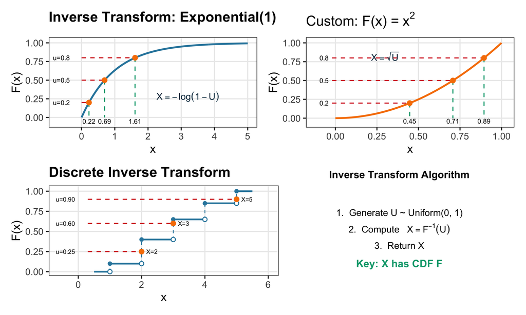

## Discrete Distributions via Inverse Transform

Given: $P[X = x_i] = p_i$ for $x_1 < x_2 < \cdots < x_k$, with $\sum p_i = 1$.

**Method 1: Linear Search**

1. Generate $U \sim \Uniform(0,1)$
2. Set $F_0 = 0$
3. For $i = 1, 2, \ldots, k$:
   - $F_i = F_{i-1} + p_i$
   - If $U \leq F_i$, return $X = x_i$

Complexity: $O(k)$ per sample

**Method 2: Binary Search**

1. Precompute $F_i = \sum_{j=1}^i p_j$
2. Generate $U \sim \Uniform(0,1)$
3. Binary search for $i$ such that $F_{i-1} < U \leq F_i$
4. Return $X = x_i$

Complexity: $O(\log k)$ per sample

The indexing rule $F_{i-1} < U \leq F_i$ is exactly $X = F^{-}(U)$.

## Six Distributions You Can Invert in Closed Form

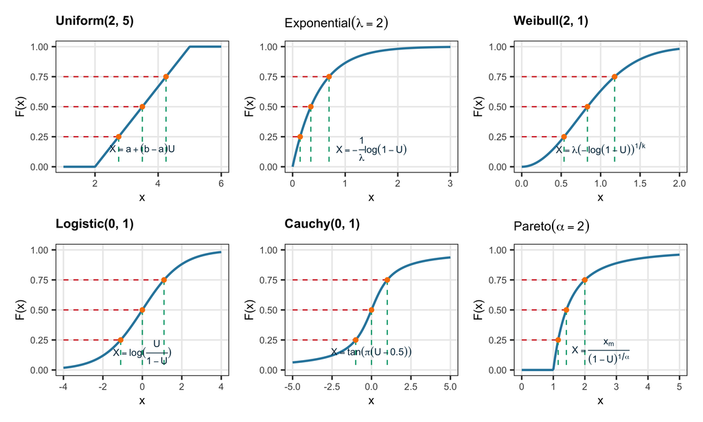

## When Inverse Transform Fails

**Limitations.**

- No closed form for $F^{-1}$ (e.g., Normal, Gamma)
- $F^{-1}$ exists but is expensive to compute
- Numerical inversion introduces errors

## The Normal Has No Closed-Form Inverse

$$F(x) = \Phi(x) = \int_{-\infty}^x \frac{1}{\sqrt{2\pi}} e^{-t^2/2}\, dt$$

- No closed form for $\Phi$ or $\Phi^{-1}$
- Numerical methods exist but are complex
- Better methods available (Box–Muller)

**Solution.** Use transformation methods or accept-reject algorithms.

## Three Routes to the Same $\Exp(1)$ Sample

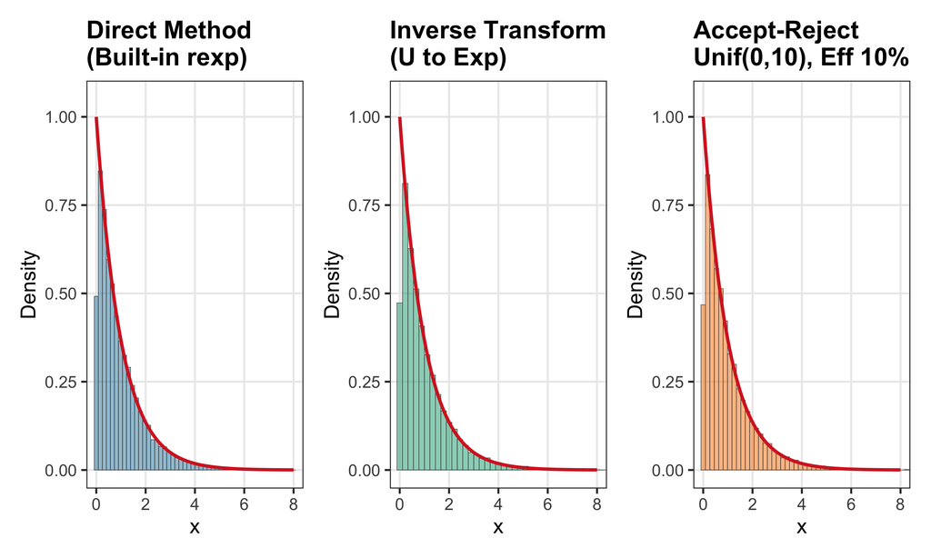

The third panel uses accept-reject, which is next week.

# Transformation Methods

## Transformation Methods: Known Relationships

**Key idea.** Use known relationships between distributions to generate complex from simple.

**Theorem (General Transformation).** If $X$ has PDF $f_X$ and $Y = g(X)$ where $g$ is strictly monotone and continuously differentiable with $g' \neq 0$ on the support of $X$, then

$$f_Y(y) = f_X(g^{-1}(y)) \left|\frac{d}{dy}g^{-1}(y)\right| .$$

Essentially, this says that the density of a transformed variable is the original density evaluated at the pre-image, scaled by how much $g^{-1}$ stretches or compresses locally.

## Simple Transformations

- If $X \sim \Normal(0,1)$, then $\mu + \sigma X \sim \Normal(\mu, \sigma^2)$
- If $X \sim \Uniform(0,1)$, then $a + (b-a)X \sim \Uniform(a,b)$
- If $X \sim \Exp(1)$, then $X/\lambda \sim \Exp(\lambda)$

## Special Relationships: Sums and Products

**Theorem (Sum of Exponentials $\to$ Gamma).** If $X_1, \ldots, X_\alpha \iid \Exp(\beta)$, then

$$Y = \sum_{i=1}^\alpha X_i \sim \Gam(\alpha, \beta)$$

when $\alpha$ is a positive integer (rate parameterization throughout: $\E[Y] = \alpha/\beta$).

We can think of this as saying that a $\Gam(\alpha, \beta)$ draw, when $\alpha$ is a positive integer, is the sum of $\alpha$ consecutive independent exponential waiting times: the time to the $\alpha$-th arrival of a rate-$\beta$ Poisson process.

**Algorithm for $\Gam(\alpha, \beta)$, $\alpha \in \mathbb{N}$.**

1. Generate $U_1, \ldots, U_\alpha \iid \Uniform(0,1)$
2. Return $Y = -\frac{1}{\beta}\sum_{i=1}^\alpha \log(U_i)$

**Special cases.** $\chi^2_k = \Gam(k/2, 1/2)$, and this algorithm applies when $k$ is even; $\Exp(\lambda) = \Gam(1, \lambda)$.

## Gamma from a Sum of Exponentials

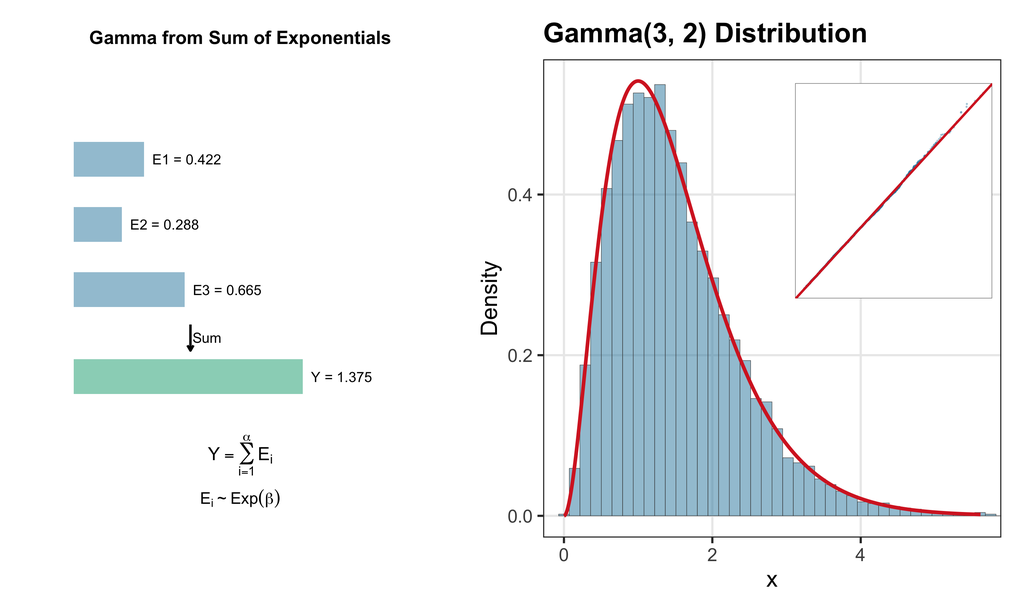

## Beta from Gamma Random Variables

**Theorem (Gamma Ratio $\to$ Beta).** If $X \sim \Gam(a, \lambda)$ and $Y \sim \Gam(b, \lambda)$ are independent, then

$$\frac{X}{X + Y} \sim \Betad(a, b) .$$

Essentially, this says that the share of the total contributed by one of two independent gamma variables, when they share the same rate, follows a beta distribution.

**Proof sketch.** Use the transformation $(U,V) = (X/(X+Y), X+Y)$ with Jacobian $J = V$.

**Algorithm for $\Betad(a, b)$, $a, b \in \mathbb{N}$.**

1. Generate $U_1, \ldots, U_a \iid \Uniform(0,1)$
2. Generate $V_1, \ldots, V_b \iid \Uniform(0,1)$
3. $X = -\sum_{i=1}^a \log(U_i)$, $Y = -\sum_{i=1}^b \log(V_i)$
4. Return $Z = X/(X+Y)$

## Box–Muller Transformation for Normal

**Theorem (Box–Muller)**

If $U_1, U_2 \iid \Uniform(0,1)$, then

$$\begin{aligned}
X_1 &= \sqrt{-2\log U_1}\, \cos(2\pi U_2) \\
X_2 &= \sqrt{-2\log U_1}\, \sin(2\pi U_2)
\end{aligned}$$

are independent $\Normal(0,1)$ random variables.

We can think of this as saying that two uniform draws, passed through the right polar-coordinate recipe, produce two independent standard normals.

## Box–Muller: Geometric Intuition

- $(X_1, X_2)$ has spherical symmetry in $\mathbb{R}^2$
- $R^2 = X_1^2 + X_2^2 \sim \chi^2_2 = \Exp(1/2)$
- $\Theta = \operatorname{atan2}(X_2, X_1) \sim \Uniform(0, 2\pi)$
- Transform from Cartesian to polar coordinates

Recall the $\Exp(\lambda)$ inverse transform from the first act of this lecture? At $\lambda = 1/2$, it gives $R^2 = -2\log U_1 \sim \chi^2_2$, so the squared radius is an inverse-transform exponential draw.

## Box–Muller: The Change of Variables

Define the transformation:

$$\begin{aligned}
R &= \sqrt{X_1^2 + X_2^2} = \sqrt{-2\log U_1}\\
\Theta &= \operatorname{atan2}(X_2, X_1) = 2\pi U_2
\end{aligned}$$

Inverting: $u_1 = e^{-(x_1^2 + x_2^2)/2}$ and $u_2 = \frac{1}{2\pi}\operatorname{atan2}(x_2, x_1)$.

Compute the Jacobian:

$$J = \det \begin{pmatrix}
\frac{\partial u_1}{\partial x_1} & \frac{\partial u_1}{\partial x_2}\\[2pt]
\frac{\partial u_2}{\partial x_1} & \frac{\partial u_2}{\partial x_2}
\end{pmatrix} = -\frac{1}{2\pi} e^{-(x_1^2 + x_2^2)/2}$$

## Box–Muller: The Joint Density Factors

Joint density of $(X_1, X_2)$:

$$f_{X_1,X_2}(x_1,x_2) = |J| \cdot 1 = \frac{1}{2\pi} e^{-(x_1^2 + x_2^2)/2}$$

This factors as two independent $\Normal(0,1)$ densities.

## From Uniform Pairs to Normal Pairs

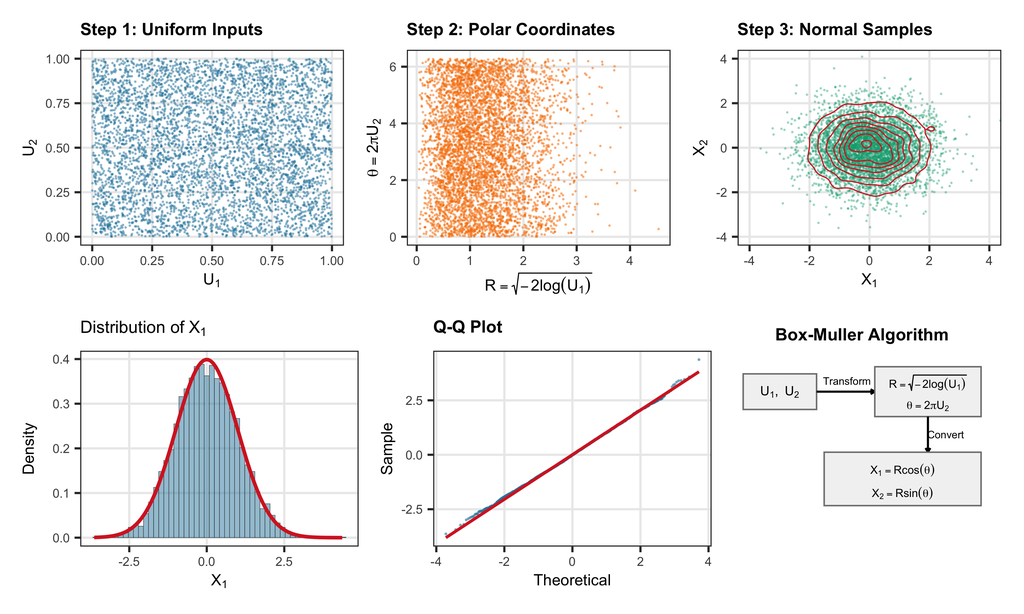

## Marsaglia’s Polar Method

**Motivation.** Avoid expensive trigonometric functions in Box–Muller.

**Algorithm.**

1. **Repeat:**
   - Generate $V_1, V_2 \iid \Uniform(-1,1)$
   - Set $S = V_1^2 + V_2^2$

   **until** $0 < S \leq 1$.
2. Set

   $$\begin{aligned}
   X_1 &= V_1\sqrt{\frac{-2\log S}{S}}\\
   X_2 &= V_2\sqrt{\frac{-2\log S}{S}}
   \end{aligned}$$

## Marsaglia’s Polar Method: Efficiency

- Expected attempts: $4/\pi \approx 1.27$
- Avoids $\sin$, $\cos$ computation
- Often faster despite rejection step

The number comes from area: the disc occupies $\pi/4 \approx 0.785$ of the square, so that is the acceptance probability.

## Accepted and Rejected Draws in the Unit Square

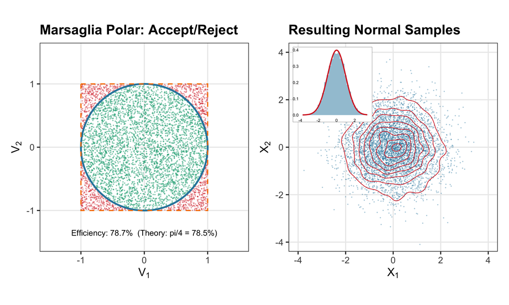

## What You Actually Do in Practice

To generate from a nonstandard target distribution $F$:

1. Write down $F$. If $F^{-}$ is closed-form, return $F^{-}(U)$. The PIT licenses this step.
2. For a discrete target, compute cumulative probabilities $F_i = \sum_{j \leq i} p_j$, search for the interval $F_{i-1} < U \leq F_i$, and return $x_i$. Same theorem.
3. Otherwise, look for a relationship to a distribution you can already draw from. The General Transformation theorem does the density bookkeeping.

R’s built-in generators already cover the standard families, each with a tuned algorithm of its own: `rnorm()` inverts $\Phi$ numerically, and `rgamma()` uses accept-reject, next week’s method. The recipe matters when the target is nonstandard: a truncated or mixture distribution, a posterior you derived yourself, or any density without a built-in generator.

# The Multivariate Normal

## Multivariate Normal via a Linear Transformation

**Theorem.** If $\mathbf{z} = (z_1, \ldots, z_p)' \sim \Normal_p(\mathbf{0}, \mathbf{I}_p)$ and $\boldsymbol{\Sigma} = \mathbf{L}\mathbf{L}'$ is positive definite (Cholesky, $\mathbf{L}$ lower triangular), then

$$\mathbf{x} = \boldsymbol{\mu} + \mathbf{L}\mathbf{z} \sim \Normal_p(\boldsymbol{\mu}, \boldsymbol{\Sigma}) .$$

Essentially, this says that multiplying independent standard normals by the Cholesky factor of $\boldsymbol{\Sigma}$ and shifting by $\boldsymbol{\mu}$ produces a draw with the desired mean and covariance structure.

## Mean and Covariance of the Transform

A linear transformation of a normal vector is normal, so only the mean and covariance need checking.

$$\E[\mathbf{x}] = \E[\boldsymbol{\mu} + \mathbf{L}\mathbf{z}] = \boldsymbol{\mu} + \mathbf{L}\,\E[\mathbf{z}] = \boldsymbol{\mu}$$

$$\Cov(\mathbf{x}) = \Cov(\mathbf{L}\mathbf{z}) = \mathbf{L}\,\Cov(\mathbf{z})\,\mathbf{L}' = \mathbf{L}\mathbf{I}_p\mathbf{L}' = \boldsymbol{\Sigma}$$

## Generating a Multivariate Normal Draw

**Algorithm.**

1. Compute the Cholesky factor $\mathbf{L}$ with $\boldsymbol{\Sigma} = \mathbf{L}\mathbf{L}'$
2. Generate $z_i \iid \Normal(0,1)$ for $i = 1, \ldots, p$
3. Return $\mathbf{x} = \boldsymbol{\mu} + \mathbf{L}\mathbf{z}$

**In R**

`chol()` returns the upper triangular factor $\mathbf{R}$ with $\boldsymbol{\Sigma} = \mathbf{R}'\mathbf{R}$, so take `L <- t(chol(Sigma))`.

## Cholesky Reshapes a Standard Normal Cloud

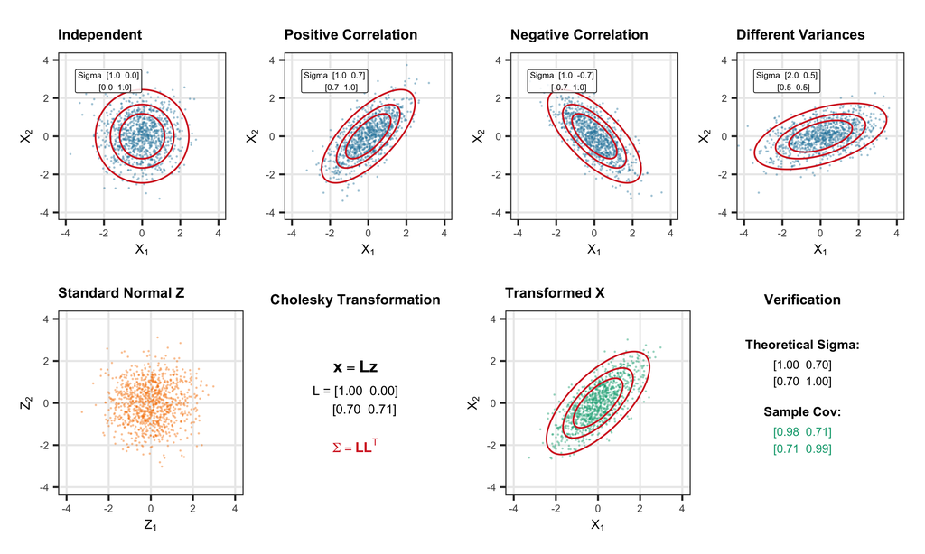

## Three Generation Strategies, Three Roles

| Result | Statement | Role |
| --- | --- | --- |
| PIT (part 1) | $F^{-}(U) \sim F$ | Uniform to any distribution with a tractable $F^{-}$ |
| General Transformation | $f_Y(y) = f_X(g^{-1}(y))\,\lvert(g^{-1})'(y)\rvert$ | A known draw to a related distribution |
| MVN Theorem | $\boldsymbol{\mu} + \mathbf{L}\mathbf{z} \sim \Normal_p(\boldsymbol{\mu}, \boldsymbol{\Sigma})$ | Independent normals to a correlated normal vector |

## Where This Leaves Us

- $F^{-}$ carries a uniform draw to any distribution whose CDF you can invert.
- A change of variables carries a pair of uniforms to a pair of normals.
- A Cholesky factor carries independent normals to a correlated normal vector.

Every method this week traces back to a uniform draw, and all three need structure you can exploit: a tractable inverse, or a relationship to a distribution you can already sample.

Next: when neither $F^{-1}$ nor a transformation is available, accept-reject.